# Airport Delays Data Analysis

### Missing Values

```r
#Identifying total number of missing values
sum(is.na(delays))
```

```
[1] 0
```

There are no missing values in the data.

```r
#Identifying the column names
colnames(delays)
```

```
 [1] "Airport.Code"                                        "Airport.Name"
 [3] "Time.Label"                                          "Time.Month"
 [5] "Time.Month.Name"                                     "Time.Year"
 [7] "Statistics...of.Delays.Carrier"                      "Statistics...of.Delays.Late.Aircraft"
 [9] "Statistics...of.Delays.National.Aviation.System"     "Statistics...of.Delays.Security"
[11] "Statistics...of.Delays.Weather"                      "Statistics.Carriers.Names"
[13] "Statistics.Carriers.Total"                           "Statistics.Flights.Cancelled"
[15] "Statistics.Flights.Delayed"                          "Statistics.Flights.Diverted"
[17] "Statistics.Flights.On.Time"                          "Statistics.Flights.Total"
[19] "Statistics.Minutes.Delayed.Carrier"                  "Statistics.Minutes.Delayed.Late.Aircraft"
[21] "Statistics.Minutes.Delayed.National.Aviation.System" "Statistics.Minutes.Delayed.Security"
[23] "Statistics.Minutes.Delayed.Total"                    "Statistics.Minutes.Delayed.Weather"
```

As there are quite a few columns it might be helpful to look at a some some subsets of the data.

We can look at three subsets specifically:

- Number of Flights Delayed Overall
- Number of Flights Delayed by Reason
- Duration of Flight Delay

```r
#Creating a character vector named flights in which we are storing column names
flights <- c("Airport.Code","Airport.Name","Time.Month","Time.Month.Name","Time.Year","Statistics.Flights.Cancelled","Statistics.Flights.Delayed","Statistics.Flights.Diverted","Statistics.Flights.On.Time","Statistics.Flights.Total")

#Creating a dataframe with information on number of delays
delays_flights <-delays[flights]

#Creating a character vector named flights in which we are storing column names
reason <- c("Airport.Code","Airport.Name","Time.Month","Time.Month.Name","Time.Year", "Statistics...of.Delays.Carrier","Statistics...of.Delays.Late.Aircraft", "Statistics...of.Delays.National.Aviation.System","Statistics...of.Delays.Security","Statistics...of.Delays.Weather")

#Creating a dataframe with information on number of delays due to different reasons
delays_reason <-delays[reason]

#Creating a character vector named duration in which we are storing column names
duration <- c("Airport.Code","Airport.Name","Time.Month","Time.Month.Name","Time.Year","Statistics.Minutes.Delayed.Carrier","Statistics.Minutes.Delayed.Late.Aircraft","Statistics.Minutes.Delayed.National.Aviation.System","Statistics.Minutes.Delayed.Security","Statistics.Minutes.Delayed.Total","Statistics.Minutes.Delayed.Weather")

#Creating a dataframe with information on duration of delays
delays_duration <-delays[duration]
```

# Flight Data: Number of Flights Delayed Overall

## Average Flights per Month

The average percentage of flights cancelled, delayed, diverted and on time between 2003-2016.

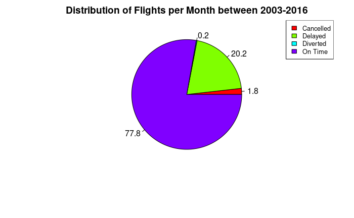

```r
#Average number of delayed flights per month since 2003
avg_flights_cancelled <- sum(delays_flights$Statistics.Flights.Cancelled)

#Average number of delayed flights per month since 2003
avg_flights_delayed <- sum(delays_flights$Statistics.Flights.Delayed)

#Average number of diverted flights per month since 2003
avg_flights_diverted <- sum(delays_flights$Statistics.Flights.Diverted)

#Average number of flights on time per month since 2003
avg_flights_on_time <- sum(delays_flights$Statistics.Flights.On.Time)

#Creating a Pie Chart
flights_values = c(avg_flights_cancelled,avg_flights_delayed,avg_flights_diverted,avg_flights_on_time )
flights_labels = c("Cancelled","Delayed","Diverted","On Time")

#Calculating the percent each will be of the total
piepercent<- round(100*flights_values/sum(flights_values), 1)

# Plot the chart.
pie(flights_values, labels = piepercent, main = "Distribution of Flights per Month between 2003-2016",col = rainbow(length(flights_values)))
legend("topright", flights_labels, cex = 0.8,fill = rainbow(length(flights_values)))
```

On average, **77.8%** of flights were On Time each month and **20.2%** of flights were Delayed.

## Average Flights per Month by Month of Year

The average percentage of flights cancelled, delayed, diverted and on time per month between 2003-2016.

```r
#Grouping by month
month <- delays_flights %>% group_by(Time.Month)

#Creating a dataframe to store the summarized values of flights cancelled each year
delays_flights_month <- month %>% summarise(Statistics.Flights.Cancelled = mean(Statistics.Flights.Cancelled))

#Renaming the columns
colnames(delays_flights_month)[which(names(delays_flights_month) == "Time.Month")] <- "Month"
colnames(delays_flights_month)[which(names(delays_flights_month) == "Statistics.Flights.Cancelled")] <- "Cancelled"

#Summarizing by number of flights delayed each year
month_delayed <- month %>% summarise(Statistics.Flights.Delayed = mean(Statistics.Flights.Delayed))

#Adding the column to delays_flights_month
delays_flights_month$Delayed <-month_delayed$Statistics.Flights.Delayed

#Summarizing by number of flights delayed
month_delayed <- month %>% summarise(Statistics.Flights.Delayed = mean(Statistics.Flights.Delayed))
delays_flights_month$Delayed <-month_delayed$Statistics.Flights.Delayed

#Summarizing by number of flights diverted
month_diverted <- month %>% summarise(Statistics.Flights.Diverted = mean(Statistics.Flights.Diverted))
delays_flights_month$Diverted <-month_diverted$Statistics.Flights.Diverted

#Summarizing by number of flights on time
month_on_time <- month %>% summarise(Statistics.Flights.On.Time = mean(Statistics.Flights.On.Time))
delays_flights_month$On_Time <-month_on_time$Statistics.Flights.On.Time

#Creating a column to display percentage of flights that were on time, on average
delays_flights_month$Percent_On_Time <-100*delays_flights_month$On_Time/(delays_flights_month$On_Time+delays_flights_month$Diverted+delays_flights_month$Delayed+delays_flights_month$Cancelled)

#Display averages for numbers of flights cancelled, delayed, diverted and on time
round(delays_flights_month)
```

| Month | Cancelled | Delayed | Diverted | On_Time | Percent_On_Time |
| --- | --- | --- | --- | --- | --- |
| 1 | 341 | 2411 | 22 | 8801 | 76 |
| 2 | 361 | 2303 | 20 | 8125 | 75 |
| 3 | 223 | 2513 | 23 | 9525 | 78 |
| 4 | 159 | 2204 | 25 | 9475 | 80 |
| 5 | 155 | 2348 | 33 | 9642 | 79 |
| 6 | 209 | 2880 | 45 | 9037 | 74 |
| 7 | 210 | 2877 | 44 | 9481 | 75 |
| 8 | 196 | 2555 | 38 | 9747 | 78 |
| 9 | 158 | 1774 | 21 | 9549 | 83 |
| 10 | 149 | 2079 | 19 | 9752 | 81 |

[output cut: 2 more lines]

```r
#Identifying month with the greatest percent of flights on time, on overage
round(delays_flights_month[which.max(delays_flights_month$Percent_On_Time),])
```

| Month | Cancelled | Delayed | Diverted | On_Time | Percent_On_Time |
| --- | --- | --- | --- | --- | --- |
| 9 | 158 | 1774 | 21 | 9549 | 83 |

```r
#Identifying year with the least percent of flights on time, on overage
round(delays_flights_month[which.min(delays_flights_month$Percent_On_Time),])
```

| Month | Cancelled | Delayed | Diverted | On_Time | Percent_On_Time |
| --- | --- | --- | --- | --- | --- |
| 12 | 287 | 2923 | 25 | 8549 | 73 |

On average, flights were on time each month the most in **September** and they were on time the least in **December.**

## Average Flights per Month by Year

The average number of flights cancelled, delayed, diverted and on time per month, each year between 2003-2016.

```r
#Grouping by year
year <- delays_flights %>% group_by(Time.Year)

#Creating a dataframe to store the summarized values of flights cancelled each year
delays_flights_year <- year %>% summarise(Statistics.Flights.Cancelled = mean(Statistics.Flights.Cancelled))

#Renaming the columns
colnames(delays_flights_year)[which(names(delays_flights_year) == "Time.Year")] <- "Year"
colnames(delays_flights_year)[which(names(delays_flights_year) == "Statistics.Flights.Cancelled")] <- "Cancelled"

#Summarizing by number of flights delayed each year
year_delayed <- year %>% summarise(Statistics.Flights.Delayed = mean(Statistics.Flights.Delayed))

#Adding the column to delays_flights_year
delays_flights_year$Delayed <-year_delayed$Statistics.Flights.Delayed

#Summarizing by number of flights delayed each year
year_delayed <- year %>% summarise(Statistics.Flights.Delayed = mean(Statistics.Flights.Delayed))
delays_flights_year$Delayed <-year_delayed$Statistics.Flights.Delayed

#Summarizing by number of flights diverted each year
year_diverted <- year %>% summarise(Statistics.Flights.Diverted = mean(Statistics.Flights.Diverted))
delays_flights_year$Diverted <-year_diverted$Statistics.Flights.Diverted

#Summarizing by number of flights on time each year
year_on_time <- year %>% summarise(Statistics.Flights.On.Time = mean(Statistics.Flights.On.Time))
delays_flights_year$On_Time <-year_on_time$Statistics.Flights.On.Time

#Creating a column to display percentage of flights that were on time each year, on average
delays_flights_year$Percent_On_Time <-100*delays_flights_year$On_Time/(delays_flights_year$On_Time+delays_flights_year$Diverted+delays_flights_year$Delayed+delays_flights_year$Cancelled)

#Display yearly averages for numbers of flights cancelled, delayed, diverted and on time
round(delays_flights_year)
```

| Year | Cancelled | Delayed | Diverted | On_Time | Percent_On_Time |
| --- | --- | --- | --- | --- | --- |
| 2003 | 170 | 2027 | 24 | 9469 | 81 |
| 2004 | 224 | 2531 | 25 | 9705 | 78 |
| 2005 | 239 | 2660 | 26 | 9643 | 77 |
| 2006 | 226 | 2944 | 32 | 9551 | 75 |
| 2007 | 295 | 3246 | 33 | 9468 | 73 |
| 2008 | 252 | 2773 | 32 | 9321 | 75 |
| 2009 | 168 | 2263 | 28 | 9147 | 79 |
| 2010 | 216 | 2105 | 28 | 9292 | 80 |
| 2011 | 223 | 2056 | 27 | 8968 | 80 |
| 2012 | 154 | 1892 | 23 | 9298 | 82 |

[output cut: 4 more lines]

```r
#Identifying year with the greatest percent of flights on time, on overage
round(delays_flights_year[which.max(delays_flights_year$Percent_On_Time),])
```

| Year | Cancelled | Delayed | Diverted | On_Time | Percent_On_Time |
| --- | --- | --- | --- | --- | --- |
| 2012 | 154 | 1892 | 23 | 9298 | 82 |

```r
#Identifying year with the least percent of flights on time, on overage
round(delays_flights_year[which.min(delays_flights_year$Percent_On_Time),])
```

| Year | Cancelled | Delayed | Diverted | On_Time | Percent_On_Time |
| --- | --- | --- | --- | --- | --- |
| 2007 | 295 | 3246 | 33 | 9468 | 73 |

On average, flights were on time each month the most in **2012** and they were on time the least in **2007.**

# Delay Reason

## Average Number Flights Delayed per Month by Reason

The average percentage of flights delayed because of carrier, aircraft, national aviation system, security and weather delays between 2003-2016.

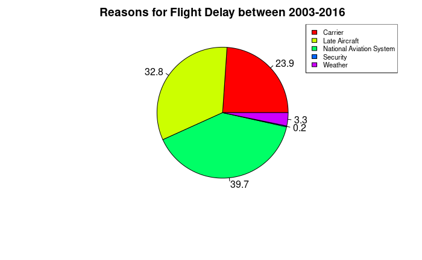

```r
#Average number of flights per month since 2003 delayed because of carriers
avg_flights_carriers <- sum(delays_reason$Statistics...of.Delays.Carrier)

#Average number of flights per month since 2003 delayed because of late arriving aircraft
avg_flights_aircraft <- sum(delays_reason$Statistics...of.Delays.Late.Aircraft)

#Average number of flights per month since 2003 delayed because of national aviation system
avg_flights_nas <- sum(delays_reason$Statistics...of.Delays.National.Aviation.System)

#Average number of flights per month since 2003 delayed because of security delays
avg_flights_security <- sum(delays_reason$Statistics...of.Delays.Security)

#Average number of flights per month since 2003 delayed because of weather
avg_flights_weather <- sum(delays_reason$Statistics...of.Delays.Weather)

#Creating a Pie Chart
reason_values = c(avg_flights_carriers,avg_flights_aircraft,avg_flights_nas, avg_flights_security, avg_flights_weather)
reason_labels = c("Carrier","Late Aircraft","National Aviation System","Security","Weather")

#Calculating the percent each will be of the total
piepercent<- round(100*reason_values/sum(reason_values), 1)

# Plot the chart.
pie(reason_values, labels = piepercent, main = "Reasons for Flight Delay between 2003-2016",col = rainbow(length(reason_values)))
legend("topright", reason_labels, cex = 0.7,fill = rainbow(length(reason_values)))
```

The three biggest reasons for flight delays are

- National Aviation System: **39.7%**
- Late Aircraft: **32.8%**
- Carrier: **23.9%**

## Delay Reason by Month of Year

```r
#Grouping by month
month <- delays_reason %>% group_by(Time.Month)

#Creating a dataframe to store the summarized values of flight delayed because of carriers
delays_reason_month <- month %>% summarise(Statistics...of.Delays.Carrier = mean(Statistics...of.Delays.Carrier))

#Renaming the columns
colnames(delays_reason_month)[which(names(delays_reason_month) == "Time.Month")] <- "Month"
colnames(delays_reason_month)[which(names(delays_reason_month) == "Statistics...of.Delays.Carrier")] <- "Carrier"

#Summarizing by flights delayed because of late aircraft
month_aircraft <- month %>% summarise(Statistics...of.Delays.Late.Aircraft = mean(Statistics...of.Delays.Late.Aircraft))

#Adding the column to delays_flights_year
delays_reason_month$Aircraft <-month_aircraft$Statistics...of.Delays.Late.Aircraft

#Summarizing by flights delayed because of national aviation system
month_nas <- month %>% summarise(Statistics...of.Delays.National.Aviation.System = mean(Statistics...of.Delays.National.Aviation.System))
delays_reason_month$National_Aviation_System<-month_nas$Statistics...of.Delays.National.Aviation.System

#Summarizing by flights delayed because of security
month_security <- month %>% summarise(Statistics...of.Delays.Security = mean(Statistics...of.Delays.Security))
delays_reason_month$Security<-month_security$Statistics...of.Delays.Security

#Summarizing by flights delayed because of weather
month_weather <- month %>% summarise(Statistics...of.Delays.Weather = mean(Statistics...of.Delays.Weather))
delays_reason_month$Weather<-month_weather$Statistics...of.Delays.Weather

#Display yearly averages for numbers of flights cancelled, delayed, diverted and on time
round(delays_reason_month)
```

| Month | Carrier | Aircraft | National_Aviation_System | Security | Weather |
| --- | --- | --- | --- | --- | --- |
| 1 | 585 | 767 | 958 | 6 | 94 |
| 2 | 532 | 743 | 940 | 5 | 83 |
| 3 | 602 | 842 | 995 | 6 | 69 |
| 4 | 521 | 723 | 898 | 5 | 58 |
| 5 | 540 | 761 | 967 | 4 | 75 |
| 6 | 681 | 987 | 1096 | 6 | 109 |
| 7 | 703 | 1011 | 1050 | 6 | 107 |
| 8 | 633 | 870 | 952 | 9 | 92 |
| 9 | 434 | 535 | 750 | 4 | 51 |
| 10 | 484 | 644 | 898 | 4 | 49 |

[output cut: 2 more lines]

```r
#Identifying month with the greatest number of delays due to each reasons for delay
round(delays_reason_month[which.max(delays_reason_month$National_Aviation_System),])
```

| Month | Carrier | Aircraft | National_Aviation_System | Security | Weather |
| --- | --- | --- | --- | --- | --- |
| 12 | 716 | 987 | 1111 | 9 | 100 |

```r
round(delays_reason_month[which.max(delays_reason_month$Aircraft),])
```

| Month | Carrier | Aircraft | National_Aviation_System | Security | Weather |
| --- | --- | --- | --- | --- | --- |
| 7 | 703 | 1011 | 1050 | 6 | 107 |

```r
round(delays_reason_month[which.max(delays_reason_month$Carrier),])
```

| Month | Carrier | Aircraft | National_Aviation_System | Security | Weather |
| --- | --- | --- | --- | --- | --- |
| 12 | 716 | 987 | 1111 | 9 | 100 |

```r
round(delays_reason_month[which.max(delays_reason_month$Weather),])
```

| Month | Carrier | Aircraft | National_Aviation_System | Security | Weather |
| --- | --- | --- | --- | --- | --- |
| 6 | 681 | 987 | 1096 | 6 | 109 |

```r
round(delays_reason_month[which.max(delays_reason_month$Security),])
```

| Month | Carrier | Aircraft | National_Aviation_System | Security | Weather |
| --- | --- | --- | --- | --- | --- |
| 12 | 716 | 987 | 1111 | 9 | 100 |

- **December** has the most delays happen due to the National Aviation System, Carrier and Security.
- **July** has the most delays due to Aircraft.
- **June** has the most delays due to Weather.

## Delay Reason by Year

```r
#Grouping by year
year <- delays_reason %>% group_by(Time.Year)

#Creating a dataframe to store the summarized values of flight delayed because of carriers
delays_reason_year <- year %>% summarise(Statistics...of.Delays.Carrier = mean(Statistics...of.Delays.Carrier))

#Renaming the columns
colnames(delays_reason_year)[which(names(delays_reason_year) == "Time.Year")] <- "Year"
colnames(delays_reason_year)[which(names(delays_reason_year) == "Statistics...of.Delays.Carrier")] <- "Carrier"

#Summarizing by flights delayed because of late aircraft
year_aircraft <- year %>% summarise(Statistics...of.Delays.Late.Aircraft = mean(Statistics...of.Delays.Late.Aircraft))

#Adding the column to delays_flights_year
delays_reason_year$Aircraft <-year_aircraft$Statistics...of.Delays.Late.Aircraft

#Summarizing by flights delayed because of national aviation system
year_nas <- year %>% summarise(Statistics...of.Delays.National.Aviation.System = mean(Statistics...of.Delays.National.Aviation.System))
delays_reason_year$National_Aviation_System<-year_nas$Statistics...of.Delays.National.Aviation.System

#Summarizing by flights delayed because of security
year_security <- year %>% summarise(Statistics...of.Delays.Security = mean(Statistics...of.Delays.Security))
delays_reason_year$Security<-year_security$Statistics...of.Delays.Security

#Summarizing by flights delayed because of weather
year_weather <- year %>% summarise(Statistics...of.Delays.Weather = mean(Statistics...of.Delays.Weather))
delays_reason_year$Weather<-year_weather$Statistics...of.Delays.Weather

#Display yearly averages for numbers of flights cancelled, delayed, diverted and on time
round(delays_reason_year)
```

| Year | Carrier | Aircraft | National_Aviation_System | Security | Weather |
| --- | --- | --- | --- | --- | --- |
| 2003 | 429 | 514 | 1000 | 7 | 76 |
| 2004 | 543 | 697 | 1180 | 9 | 102 |
| 2005 | 628 | 775 | 1155 | 6 | 95 |
| 2006 | 701 | 931 | 1200 | 10 | 101 |
| 2007 | 785 | 1062 | 1276 | 8 | 114 |
| 2008 | 624 | 881 | 1173 | 5 | 90 |
| 2009 | 501 | 710 | 976 | 4 | 72 |
| 2010 | 513 | 729 | 797 | 5 | 62 |
| 2011 | 499 | 733 | 764 | 4 | 56 |
| 2012 | 495 | 693 | 647 | 4 | 53 |

[output cut: 4 more lines]

```r
#Identifying year with the greatest number of delays due to each reasons for delay
round(delays_reason_year[which.max(delays_reason_month$National_Aviation_System),])
```

| Year | Carrier | Aircraft | National_Aviation_System | Security | Weather |
| --- | --- | --- | --- | --- | --- |
| 2014 | 578 | 853 | 789 | 3 | 66 |

```r
round(delays_reason_year[which.max(delays_reason_month$Aircraft),])
```

| Year | Carrier | Aircraft | National_Aviation_System | Security | Weather |
| --- | --- | --- | --- | --- | --- |
| 2009 | 501 | 710 | 976 | 4 | 72 |

```r
round(delays_reason_year[which.max(delays_reason_month$Carrier),])
```

| Year | Carrier | Aircraft | National_Aviation_System | Security | Weather |
| --- | --- | --- | --- | --- | --- |
| 2014 | 578 | 853 | 789 | 3 | 66 |

```r
round(delays_reason_year[which.max(delays_reason_month$Weather),])
```

| Year | Carrier | Aircraft | National_Aviation_System | Security | Weather |
| --- | --- | --- | --- | --- | --- |
| 2008 | 624 | 881 | 1173 | 5 | 90 |

```r
round(delays_reason_year[which.max(delays_reason_month$Security),])
```

| Year | Carrier | Aircraft | National_Aviation_System | Security | Weather |
| --- | --- | --- | --- | --- | --- |
| 2014 | 578 | 853 | 789 | 3 | 66 |

# Delay Duration

## Average Duration of Delay per Month by Reason

The average duration of delay because of carrier, aircraft, national aviation system, security and weather delays between 2003-2016.

```r
#Average duration of delay per month since 2003 delayed because of carriers
avg_flights_carriers <- mean(delays_duration$Statistics.Minutes.Delayed.Carrier)

#Average duration of delay per month since 2003 delayed because of late arriving aircraft
avg_flights_aircraft <- mean(delays_duration$Statistics.Minutes.Delayed.Late.Aircraft)

#Average duration of delay per month since 2003 delayed because of national aviation system
avg_flights_nas <- mean(delays_duration$Statistics.Minutes.Delayed.National.Aviation.System)

#Average duration of delay per month since 2003 delayed because of security delays
avg_flights_security <- mean(delays_duration$Statistics.Minutes.Delayed.Security)

#Average duration of delay per month since 2003 delayed because of weather
avg_flights_weather <- mean(delays_duration$Statistics.Minutes.Delayed.Weather)

#Creating a Bar Plot with values displayed on top of bars
duration_values = c(avg_flights_carriers,avg_flights_aircraft,avg_flights_nas, avg_flights_security, avg_flights_weather)
duration_values = round(duration_values)
duration_labels = c("Carrier","Late Aircraft","National Aviation System","Security","Weather")

## Make the duration values numbers (rather than factors)
duration_values <- as.numeric(as.character(duration_values))

## Find a range of y's that'll leave sufficient space above the tallest bar
ylim <- c(0, 1.1*max(duration_values))

## Plot, and store x-coordinates of bars in xx
xx <- barplot(duration_values,main ="Average Duration of Delay per Month by Reason", col=rainbow(length(duration_values)), ylim = ylim)

## Add text at top of bars
text(x = xx, y = duration_values, label = duration_values, pos = 3, cex = 0.8, col = "red")
```

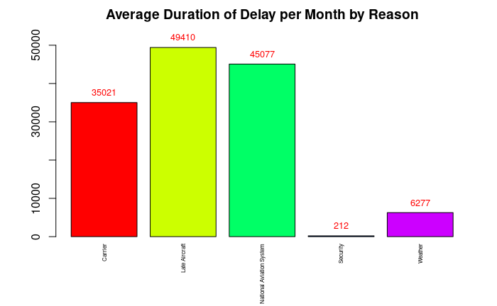

```r
## Add x-axis labels
axis(1, at=xx, labels=duration_labels, tick=FALSE, las=2, line=-0.5, cex.axis=0.5)
```

The longest delays were from three main sources:

- Late Aircraft resulted in the longest delays, averaging a total of 49,410 minutes each month.
- National Aviation System resulted in delays averaging a total of 45,077 minutes each month.
- Carriers resulted in delays averaging a total of 35,021 minutes each month.

## Delay Duration by Month of Year

```r
#Grouping by month
month <- delays_duration %>% group_by(Time.Month)

#Creating a dataframe to store the summarized values of flight delayed because of carriers
delays_duration_month <- month %>% summarise(Statistics.Minutes.Delayed.Carrier = mean(Statistics.Minutes.Delayed.Carrier))

#Renaming the columns
colnames(delays_duration_month)[which(names(delays_duration_month) == "Time.Month")] <- "Month"
colnames(delays_duration_month)[which(names(delays_duration_month) == "Statistics.Minutes.Delayed.Carrier")] <- "Carrier"

#Summarizing by flights delayed because of late aircraft
month_aircraft <- month %>% summarise(Statistics.Minutes.Delayed.Late.Aircraft = mean(Statistics.Minutes.Delayed.Late.Aircraft))

#Adding the column to delays_flights_year
delays_duration_month$Aircraft <-month_aircraft$Statistics.Minutes.Delayed.Late.Aircraft

#Summarizing by flights delayed because of national aviation system
month_nas <- month %>% summarise(Statistics.Minutes.Delayed.National.Aviation.System=mean(Statistics.Minutes.Delayed.National.Aviation.System))
delays_duration_month$National_Aviation_System<-month_nas$Statistics.Minutes.Delayed.National.Aviation.System

#Summarizing by flights delayed because of security
month_security <- month %>% summarise(Statistics.Minutes.Delayed.Security = mean(Statistics.Minutes.Delayed.Security))
delays_duration_month$Security<-month_security$Statistics.Minutes.Delayed.Security

#Summarizing by flights delayed because of weather
month_weather <- month %>% summarise(Statistics.Minutes.Delayed.Weather = mean(Statistics.Minutes.Delayed.Weather))
delays_duration_month$Weather<-month_weather$Statistics.Minutes.Delayed.Weather

#Summarizing by total delay
month_total <- month %>% summarise(Statistics.Minutes.Delayed.Total = mean(Statistics.Minutes.Delayed.Total))
delays_duration_month$Total<-month_total$Statistics.Minutes.Delayed.Total

#Display yearly averages for numbers of flights cancelled, delayed, diverted and on time
round(delays_duration_month)
```

| Month | Carrier | Aircraft | National_Aviation_System | Security | Weather | Total |
| --- | --- | --- | --- | --- | --- | --- |
| 1 | 35825 | 48043 | 43494 | 228 | 7519 | 135109 |
| 2 | 32396 | 45667 | 42320 | 180 | 6849 | 127412 |
| 3 | 36008 | 52064 | 46296 | 201 | 5568 | 140138 |
| 4 | 31593 | 43923 | 41179 | 180 | 4559 | 121434 |
| 5 | 32885 | 47559 | 46354 | 154 | 6160 | 133112 |
| 6 | 43110 | 66186 | 56875 | 236 | 9208 | 175614 |
| 7 | 44547 | 67893 | 55365 | 211 | 8691 | 176707 |
| 8 | 39115 | 55387 | 46652 | 338 | 7089 | 148580 |
| 9 | 26455 | 31320 | 33340 | 158 | 3690 | 94962 |
| 10 | 28391 | 36938 | 39162 | 158 | 3752 | 108400 |

[output cut: 2 more lines]

```r
#Identifying month with the greatest duration of delays due to each reason
round(delays_duration_month[which.max(delays_duration_month$Total),])
```

| Month | Carrier | Aircraft | National_Aviation_System | Security | Weather | Total |
| --- | --- | --- | --- | --- | --- | --- |
| 7 | 44547 | 67893 | 55365 | 211 | 8691 | 176707 |

```r
round(delays_duration_month[which.max(delays_duration_month$National_Aviation_System),])
```

| Month | Carrier | Aircraft | National_Aviation_System | Security | Weather | Total |
| --- | --- | --- | --- | --- | --- | --- |
| 6 | 43110 | 66186 | 56875 | 236 | 9208 | 175614 |

```r
round(delays_duration_month[which.max(delays_duration_month$Aircraft),])
```

| Month | Carrier | Aircraft | National_Aviation_System | Security | Weather | Total |
| --- | --- | --- | --- | --- | --- | --- |
| 7 | 44547 | 67893 | 55365 | 211 | 8691 | 176707 |

```r
round(delays_duration_month[which.max(delays_duration_month$Carrier),])
```

| Month | Carrier | Aircraft | National_Aviation_System | Security | Weather | Total |
| --- | --- | --- | --- | --- | --- | --- |
| 7 | 44547 | 67893 | 55365 | 211 | 8691 | 176707 |

```r
round(delays_duration_month[which.max(delays_duration_month$Weather),])
```

| Month | Carrier | Aircraft | National_Aviation_System | Security | Weather | Total |
| --- | --- | --- | --- | --- | --- | --- |
| 6 | 43110 | 66186 | 56875 | 236 | 9208 | 175614 |

```r
round(delays_duration_month[which.max(delays_duration_month$Security),])
```

| Month | Carrier | Aircraft | National_Aviation_System | Security | Weather | Total |
| --- | --- | --- | --- | --- | --- | --- |
| 8 | 39115 | 55387 | 46652 | 338 | 7089 | 148580 |

Overall, **July** has the longest delays.

- **June** has the longest delays due to the National Aviation System and Weather.
- **July** has the longest delays due to Aircraft and Carrier.
- **August** has the longest delays due to Security.

## Delay Duration by Year

```r
#Grouping by year
year <- delays_duration %>% group_by(Time.Year)

#Creating a dataframe to store the summarized values of flight delayed because of carriers
delays_duration_year <- year %>% summarise(Statistics.Minutes.Delayed.Carrier = mean(Statistics.Minutes.Delayed.Carrier))

#Renaming the columns
colnames(delays_duration_year)[which(names(delays_duration_year) == "Time.Year")] <- "Year"
colnames(delays_duration_year)[which(names(delays_duration_year) == "Statistics.Minutes.Delayed.Carrier")] <- "Carrier"

#Summarizing by flights delayed because of late aircraft
year_aircraft <- year%>% summarise(Statistics.Minutes.Delayed.Late.Aircraft = mean(Statistics.Minutes.Delayed.Late.Aircraft))
delays_duration_year$Aircraft <-year_aircraft$Statistics.Minutes.Delayed.Late.Aircraft

#Summarizing by flights delayed because of national aviation system
year_nas <- year %>% summarise(Statistics.Minutes.Delayed.National.Aviation.System=mean(Statistics.Minutes.Delayed.National.Aviation.System))
delays_duration_year$National_Aviation_System<-year_nas$Statistics.Minutes.Delayed.National.Aviation.System

#Summarizing by flights delayed because of security
year_security <- year %>% summarise(Statistics.Minutes.Delayed.Security = mean(Statistics.Minutes.Delayed.Security))
delays_duration_year$Security<-year_security$Statistics.Minutes.Delayed.Security

#Summarizing by flights delayed because of weather
year_weather <- year %>% summarise(Statistics.Minutes.Delayed.Weather = mean(Statistics.Minutes.Delayed.Weather))
delays_duration_year$Weather<-year_weather$Statistics.Minutes.Delayed.Weather

#Summarizing by total delay
year_total <- year %>% summarise(Statistics.Minutes.Delayed.Total = mean(Statistics.Minutes.Delayed.Total))
delays_duration_year$Total<-year_total$Statistics.Minutes.Delayed.Total

#Display yearly averages for numbers of flights cancelled, delayed, diverted and on time
round(delays_duration_year)
```

| Year | Carrier | Aircraft | National_Aviation_System | Security | Weather | Total |
| --- | --- | --- | --- | --- | --- | --- |
| 2003 | 24198 | 29963 | 44153 | 263 | 5786 | 104362 |
| 2004 | 30136 | 41868 | 54051 | 346 | 7533 | 133934 |
| 2005 | 34897 | 47239 | 54387 | 230 | 7097 | 143851 |
| 2006 | 39688 | 57667 | 58372 | 383 | 7676 | 163786 |
| 2007 | 46285 | 67367 | 63368 | 305 | 9292 | 186617 |
| 2008 | 39092 | 56628 | 59102 | 196 | 7620 | 162638 |
| 2009 | 30864 | 43480 | 46178 | 139 | 5792 | 126452 |
| 2010 | 31248 | 44006 | 36484 | 182 | 4921 | 116842 |
| 2011 | 31484 | 45919 | 34854 | 143 | 4701 | 117101 |
| 2012 | 32049 | 43990 | 28883 | 135 | 4305 | 109362 |

[output cut: 4 more lines]

```r
#Identifying year with the greatest duration of delays due to each reason
round(delays_duration_year[which.max(delays_duration_year$Total),])
```

| Year | Carrier | Aircraft | National_Aviation_System | Security | Weather | Total |
| --- | --- | --- | --- | --- | --- | --- |
| 2007 | 46285 | 67367 | 63368 | 305 | 9292 | 186617 |

```r
round(delays_duration_year[which.max(delays_duration_year$National_Aviation_System),])
```

| Year | Carrier | Aircraft | National_Aviation_System | Security | Weather | Total |
| --- | --- | --- | --- | --- | --- | --- |
| 2007 | 46285 | 67367 | 63368 | 305 | 9292 | 186617 |

```r
round(delays_duration_year[which.max(delays_duration_year$Aircraft),])
```

| Year | Carrier | Aircraft | National_Aviation_System | Security | Weather | Total |
| --- | --- | --- | --- | --- | --- | --- |
| 2007 | 46285 | 67367 | 63368 | 305 | 9292 | 186617 |

```r
round(delays_duration_year[which.max(delays_duration_year$Carrier),])
```

| Year | Carrier | Aircraft | National_Aviation_System | Security | Weather | Total |
| --- | --- | --- | --- | --- | --- | --- |
| 2007 | 46285 | 67367 | 63368 | 305 | 9292 | 186617 |

```r
round(delays_duration_year[which.max(delays_duration_year$Weather),])
```

| Year | Carrier | Aircraft | National_Aviation_System | Security | Weather | Total |
| --- | --- | --- | --- | --- | --- | --- |
| 2007 | 46285 | 67367 | 63368 | 305 | 9292 | 186617 |

```r
round(delays_duration_year[which.max(delays_duration_year$Security),])
```

| Year | Carrier | Aircraft | National_Aviation_System | Security | Weather | Total |
| --- | --- | --- | --- | --- | --- | --- |
| 2006 | 39688 | 57667 | 58372 | 383 | 7676 | 163786 |

Overall, **2007** has the longest delays.

- **2007** has the longest delays due to the National Aviation System, Aircraft, Carrier and Weather.
- **2006** has the longest delays due to Security.

# Summary of Data Analysis

On average, **77.8%** of flights were On Time each month and **20.2%** of flights were Delayed.

The three biggest reasons for flight delays are:

- National Aviation System accounts for **39.7%** of all delays, averaging a total of 45,077 minutes each month.
- Late Aircraft accounts for **32.8%** of all delays, averaging a total of 49,410 minutes each month, which is the **longest** delay.
- Carrier accounts for **23.9%** of all delays, averaging a total of 35,021 minutes each month.

The most delays occur in the month of **December**, which can be accounted towards the National Aviation System, Carrier and Security.

The longest delays occur in the month of **July**, which can be accounted towards the Aircraft and Carrier.

The most delays occur in the year **2007.**

- These delays can be accounted towards the National Aviation System, Aircraft, Carrier and Weather.
- This is also the year with the longest delays overall.